# Test for Consultancy with the D&A Education Team

Application for the position of data scientist

2025-07-28

The average proportion of births in 2022 that are expected to have benefited from at least four prenatal visits is 17.5 percentage points higher in countries that are “on track” than in those that are “off track”. Similarly, the average proportion of births expected in 2022 that should be attended by health professionals is 23.8 percentage points higher in countries “on track” than in those “off track.”

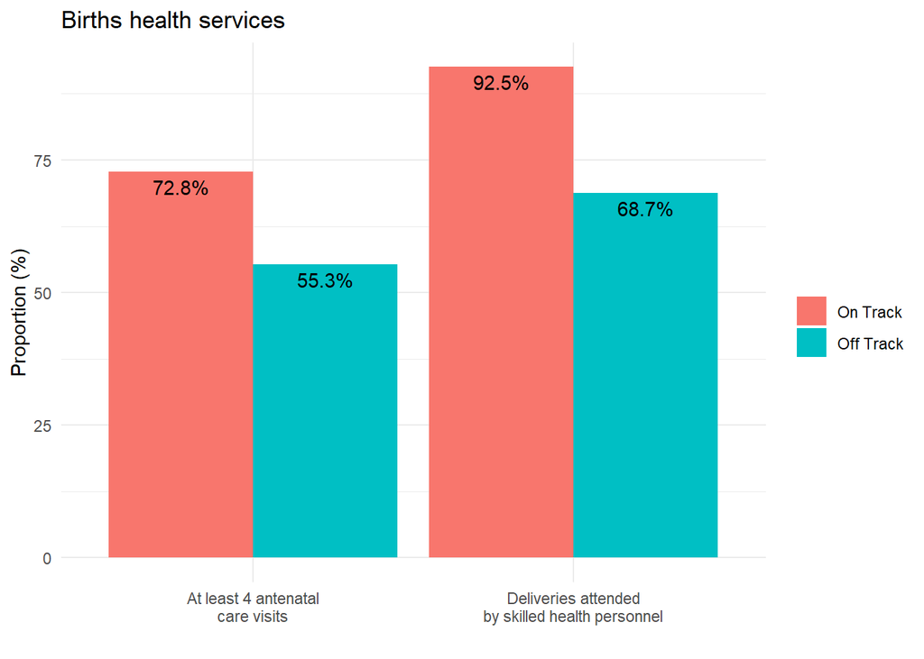

These indicators assume continuity of health services in 2022 compared to the last available year and therefore, in some cases, compared to 2018. The COVID-19 pandemic and the multiple tensions it has caused in the health sector should make us rethink this assumption.